# Classification

Tony

Tue Jun 13 18:44:50 2017

# 1 Introduction

This project describes my experimentation/experience with creating classification models to predict whether or not an NBA team will go over or under the number of wins projected by sportsbooks. The inspiration for this project is multi-faceted: 1. My brother and I have been picking over/unders for NBA teams dating back to 2012 and have always been fascinated with sports gambling (alhtough we have never actually participated ourselves). I wanted to evaluate our picks in some way, perhaps to create a model that could make accurate win total picks for me. If I can create something good enough, then maybe one day I will be confident enough to actually place a bet! 2. I wanted a project to help me develop my R skills. 3. I wanted to practice some of the statistical and machine learning techniques that I have studied and read about all the time.

Alhtough my brother and I have only been recording our over/under picks since 2012, I will be looking at NBA seasons from 2007 to 2016 because I have win totals going back to the 2007 season. Notably, my brother and I also submitted “confidence ratings” gauging our level of confidence in our picks starting in 2014. (These ratings go from 1 to 30, where 1 is our most confident pick and 30 is our least.)

Although I would like to use and/or evaluate our “personal” data (i.e. picks) to possibly create better models (perhaps by exposing our internal biases/ tendencies and identifying where we might “fade” our initial picks), I won’t be using this pick data in this part of the project. I’ll leave that for another time. Thus, it is not problemmatic that I will be investigating years which we did not record picks (or submit confidence ratings). Nevertheless, some evidence of code that includes some of this “personal” data may be evident in the code that follows because I evaluated it during the development of this project.

In this portion of the project, I’ll evaulate different models while keeping the model formula constant. Although choice of model formula is a significant decision in and of itself, my purpose here is to compare classification models. I’ll evaluate differen formulas in another portion of this project. Nevertheless, I’ll use my best judgement and intuition in my selection of the model formula to be used.

Finally, as a note to those who are interesting in code style, I attempt to implement the “tidy” workflow promoted by Hadley Wickham and many other prominent R community members. This approach advocates initial steps of importing and tidying data; followed by a cycle of transforming, modeling, and analyzing the data; and, finally, communicating the results.

# 2 Importing the Data

I start by loading in the data set for stats and team win totals. I have saved this data in local rds files for use across multiple projects.

One might notice a couple of things about my naming of variables: + I generally use the prefix “d_” in order to distinguish data. This is a personal convention that I picked up from traces of things in other languages (variable naming with VBA and table naming with Oracle SQL). + I tend to use the suffix “_raw" if the variable is going to be manipulated/transformed in some way. + Sometimes, when I create a new variable that copies all or most of the data from an existing variable, I append the new variable’s name with the suffix “_2“,”_3“, etc. I do this for one of two reason: 1. This might be done for ease in debugging/developing the code because it helps me confirm that the changes that I intended to make actually do take effect when re-running a certain chunk of code multiple times. The variables that get created in this manner might be deemed”temporary“. I realize that this is not exactly a”best practice“, but it works for me. 2. At other times, such as when I’m looking at different models that are from the same family of models, then I’ll use the suffix to simply distinguish that the variable is similar to another variable (and has the same dimenstions, etc.) but there is something intentionally different about the way it has been defined.

```r
dir_data <- paste0(getwd(), "/data/")
d_win_totals_raw <- readRDS(paste0(dir_data, "d_win_totals.rds"))
p_win_totals_raw <- readRDS(paste0(dir_data, "p_win_totals.rds"))
```

# 3 Tidying and Transforming the Data

Now I’ll tidy and transform.

```r
library(tidyverse)

# Selecting only the desired columns.
# dplyr's select() function may conflict with other packages.


p_win_totals <- p_win_totals_raw %>%
  dplyr::select(one_of(c("pick_id",
                         "person",
                         "pick",
                         "confidence")))

yrs <- 2007:2016
# Not only selecting the desired columns, but also adding
# some variables to (possibly) be used in models.
# The inner_join might not work if the team columns is not of the same type
# in each data set. (It must be either a character/factor in both data sets.)
d_win_totals <- d_win_totals_raw %>%
  filter(yr_start %in% yrs) %>%
  dplyr::select(
    one_of(
      "pick_id",
      "yr_start",
      "team",
      "w",
      "w_sportsbook",
      "odds_over",
      "odds_under"
    )
  ) %>%
  #   group_by(yr_start) %>%
  #   mutate(w_rnk = dense_rank(desc(w)),
  #   w_sportsbook_rnk = dense_rank(desc(w_sportsbook))) %>%
  #   ungroup() %>%
  group_by(team) %>%
  mutate(w_lag1 = lag(w),
         w_diff2 = (lag(w) - lag(w, 2))) %>%
  # ungroup() %>%
  # group_by(yr_start) %>%
  # mutate(w_diff2_rnk = dense_rank(desc(w_diff2))) %>%
  ungroup() %>%
  mutate(result =
           ifelse(w > w_sportsbook, "O", "U")) %>%
  # ifelse(w > w_sportsbook, 1, -1)) %>%
  ungroup() %>%
  group_by(team) %>%
  mutate(result_lag1 = lag(result),
         w_sportsbook_err1 = (lag(w) - lag(w_sportsbook))) %>%
  ungroup() %>%
  mutate(
    prob_implied_over =
      ifelse(
        odds_over < 0,-odds_over / (-odds_over + 100),
        ifelse(odds_over > 0, 100 / (odds_over + 100), 0)
      ),
    prob_implied_under =
      ifelse(
        odds_under < 0,-odds_under / (-odds_under + 100),
        ifelse(odds_under > 0, 100 / (odds_under + 100), 0)
      ),
    prob_implied_combo = prob_implied_over - prob_implied_under,
    # underdog_over =
    #   ifelse(odds_over > 0, 1,
    #          ifelse(odds_over < 0, 0, 0)),
    # underdog_under =
    #   ifelse(odds_under > 0, 1,
    #          ifelse(odds_under < 0, 0, 0)),
    underdog_combo = ifelse(odds_over > 0, 1, ifelse(odds_under > 0,-1, 0))
  )

d_win_totals$result <- factor(d_win_totals$result)
d_win_totals$result_lag1 <- factor(d_win_totals$result_lag1)
d_win_totals$underdog_combo <- factor(d_win_totals$underdog_combo)

# Could replace years with no odds with a constant values such as -110,
# but choosing to exclude them instead.
# d_win_totals$odds_over <-
#   as.numeric(str_replace_all(d_win_totals$odds_over, "na", -110))
# d_win_totals$odds_under <-
#   as.numeric(str_replace_all(d_win_totals$odds_under, "na", -110))

# The "pick_id" field in the rds data sets serves as a primary key
# upon which the pick data can be joined with the other data.
# Converting a confidence rating to a win number for potential use in modeling.
d_join <- d_win_totals %>%
  left_join(p_win_totals, by = "pick_id") %>%
  dplyr::select(-pick_id) %>%
  mutate(
    pick_result =
      ifelse(pick == result, 1, 0),
    w_pick_confidence =
      ifelse(
        confidence == 0,
        ifelse(
          pick == "O",
          round(w_sportsbook + 1.5, 0),
          round(w_sportsbook - 1.5, 0)
        ),
        ifelse(pick == "O",
               round(w_sportsbook + (3 - confidence / 10), 0),
               round(w_sportsbook - (3 - confidence / 10), 0))
      )
  )
# pick_int = ifelse(pick == "O", 1, -1)) %>%
# dplyr::select(-pick) %>%
# rename(pick = pick_int)
```

Now I’ll save this data for potential use in other projects.

```r
saveRDS(d_join, file = paste0(dir_data, "d_join_classification", ".rds"))
```

# 4 Modeling the Data

Because there is duplicate information in my final tidy data set due to there being two people for whom picks were tracked, I’ll filter the data set to just distinct results. I’m not going to evaluate the picks that my brother and I made yet (even though I did some calculations with this data above).

```r
d_model <- d_join %>% dplyr::select(-team, -person, -pick, -confidence, -pick_result,
    -w_pick_confidence) %>% distinct()
```

For my analysis, I’m going to use the `result` variable as the response variable that I’ll be trying to predict, and only a handful of the remaining variables as predictors. But which predictors to choose? Let’s look at some correlations between possible predictor variables.

```r
names_x_plausible <- c("w_lag1", "w_diff2", "result_lag1", "w_sportsbook_err1",
    "prob_implied_combo", "underdog_combo")
d_model_x <- d_model %>% dplyr::select(one_of(names_x_plausible))

library(polycor)
# Need as.data.frame() because tibbles are interpreted as lists.
d_cor <- hetcor(as.data.frame(d_model_x))
d_cor$correlations <- round(d_cor$correlations, 2)
d_cor$correlations
```

```
##                    w_lag1 w_diff2 result_lag1 w_sportsbook_err1
## w_lag1               1.00    0.45       -0.50              0.56
## w_diff2              0.45    1.00       -0.67              0.65
## result_lag1         -0.50   -0.67        1.00             -0.99
## w_sportsbook_err1    0.56    0.65       -0.99              1.00
## prob_implied_combo  -0.08    0.00       -0.01             -0.03
## underdog_combo       0.12    0.02       -0.02              0.06
##                    prob_implied_combo underdog_combo
## w_lag1                          -0.08           0.12
## w_diff2                          0.00           0.02
## result_lag1                     -0.01          -0.02
## w_sportsbook_err1               -0.03           0.06
## prob_implied_combo               1.00          -0.98
## underdog_combo                  -0.98           1.00
```

I’m also going to remove the `w_lag1` variable for intuitional reasons. The raw number of wins that a team had in the previous season shouldn’t have any effect on whether or not the team exceeds its win total in the current season.

```r
names_x <- c("w_sportsbook_err1", "prob_implied_combo")
d_model_x_2 <- d_model %>% dplyr::select(one_of(names_x))

d_cor_2 <- hetcor(as.data.frame(d_model_x_2))
d_cor_2$correlations <- round(d_cor_2$correlations, 2)
d_cor_2$correlations
```

```
##                    w_sportsbook_err1 prob_implied_combo
## w_sportsbook_err1               1.00              -0.04
## prob_implied_combo             -0.04               1.00
```

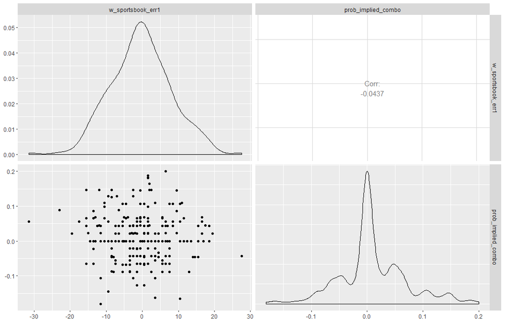

```r
# A visualization of variable relationships.
library(GGally)
ggpairs(d_model_x_2)
```

```r
# A visualization of just the correlations.  ggcorr(d_cor$correlations,
# palette = 'RdBu', label = TRUE)
```

Alternatively, I could have taken a more systematic approach. I could run a subsetting algorithm on all possible predictors and see what turns out to be “optimal”.

```r
library(leaps)
name_y <- "result"
names_exclude <- c("yr_start", "result", "w", "w_sportsbook")
names_x_all <- names(d_model)[!(names(d_model) %in% names_exclude)]

# Cannot have NA's in data.matrix
d_x <- data.matrix(dplyr::select(filter(d_model, yr_start > 2008), one_of(names_x_all)))
d_y <- data.matrix(dplyr::select(filter(d_model, yr_start > 2008), result))
subset_fit_full <- regsubsets(d_x, d_y, nvmax = length(names_x_all))
```

```
## Reordering variables and trying again:
```

There are several different criteria that could be used to choose model parameters. I’ll look at Adjusted R^2, Cp, and BIC.

```r
subset_summary <- summary(subset_fit_full)
subset_summary
```

[output not shown]

```r
which.max(subset_summary$adjr2)
```

```
## [1] 3
```

```r
which.min(subset_summary$cp)
```

```
## [1] 2
```

```r
which.min(subset_summary$bic)
```

```
## [1] 1
```

```r
coef(subset_fit_full, which.max(subset_summary$adjr2))
```

```
##       (Intercept)        odds_under           w_diff2 prob_implied_over
##       2.520385348      -0.000575764       0.004507513      -1.901128151
```

```r
coef(subset_fit_full, which.min(subset_summary$cp))
```

```
##    (Intercept)        w_diff2 underdog_combo
##    1.224532667    0.004622503    0.160496068
```

```r
coef(subset_fit_full, which.min(subset_summary$bic))
```

```
##    (Intercept) underdog_combo
##      1.2216981      0.1619497
```

It looks like these critiera each select a small number of parameters, including some of the variables that I identified as signficant. Each criterion suggests variables that are not collinear with others. I’ll stick with my heurestically chosen formula for now, but when it comes time to expermenting with different formulas, I’ll take a second look at the variables identified by this subsetting algorithm.

Alright, that’s enough of that. Let’s get to some model experimentation. Here are the variables and formula that I’ll be using. To predict whether or not a given team will go over or under its win total in a given year, I will be using the difference between the sportbook win total in predicting a given team’s number of wins from the previous year and a singular number that combines the implied probability of the moneyline odds for the over and under.

```r
name_y <- "result"
names_x <- c("w_sportsbook_err1", "prob_implied_combo")
fmla <- paste(name_y, paste(names_x, collapse = " + "), sep = " ~ ")
```

```r
# fmla <- 'result ~ w_sportsbook_err1 + prob_implied_combo'
```

## 4.1 Logisitic Regression

Now I’ll start with a fairly well known family of models: logistic regression. I’ll fit a model on the entire data set just to check that everything works.

```r
lr_fit_full <- glm(fmla, data = d_model, family = binomial)
summary(lr_fit_full)$coef
```

```
##                      Estimate Std. Error    z value     Pr(>|z|)
## (Intercept)         0.2285968 0.12815565  1.7837432 0.0744654040
## w_sportsbook_err1   0.0130851 0.01499308  0.8727425 0.3828034291
## prob_implied_combo -7.3953404 2.08406617 -3.5485152 0.0003874097
```

```r
coef(lr_fit_full)
```

```
##        (Intercept)  w_sportsbook_err1 prob_implied_combo
##          0.2285968          0.0130851         -7.3953404
```

It looks like this model isn’t all too bad. It certainly could be worse. However, even after my process of trying to identify the best predictors to use heuristically, the p-values indicate that only one of the predictors is signficant. This actually might not be a flaw in my selection process. It could just be that there isn’t a great combination of predictors out of those available. Anyways, I’ll leave formula experimentation for another portion of this project.

```r
lr_prob_full <- predict(lr_fit_full, type = "response")
lr_pred_full <- rep("U", dim(d_model)[1])
```

```r
# lr_pred_full[lr_prob_full > 0.5] = 'O'
lr_pred_full[lr_prob_full > mean(lr_prob_full)] = "O"
table(lr_pred_full, d_model$result)
```

```
##
## lr_pred_full  O  U
##            O 88 74
##            U 54 84
```

```r
round(mean(lr_pred_full == d_model$result), 2)
```

```
## [1] 0.57
```

So it isn’t the worst model one could possibly come up with. Atleast it better than 50% in predicitng over/unders when trained and tested on the full data set.

But how much worse (or better) might the prediction performance get when properly trained and tested on different sets? I’ll forego the creation of a validation set for now since I’m not explicity trying to refine some cost parameter or another kind of tuning parameter. Instead, I’m simply going to split the data into train and test sets. This could be done in a number of ways, such as random sampling. However, I’m simply going to use a single year’s worth of data as a test set and the rest as the train set. I’ll do this for every year. This is essentially “leave-one-out cross validation” (LOOCV).

I’ll save some of the prediction performance data so that I can compare other models with this one.

```r
lr_mean_pct <- list()
for (i in 1:length(yrs)) {
    vector_train <- !(d_model$yr_start %in% yrs[i])

    d_model_test <- d_model[!vector_train, ]
    d_y_test <- d_model$result[!vector_train]

    # Not sure why this isn't working.  lr_fit_train <- glm(fmla, data =
    # d_model, family = binomial, subset = vector_train) This is an alternative.
    d_model_train <- d_model[vector_train, ]
    lr_fit_train <- glm(fmla, data = d_model_train, family = binomial)
    lr_prob_test <- predict(lr_fit_train, d_model_test, type = "response")
    lr_pred_test <- rep("U", dim(d_model_test)[1])
    # lr_pred_test[lr_prob_test > 0.5] = 'O'
    lr_pred_test[lr_prob_test > mean(lr_prob_test)] = "O"
    lr_mean_pct[i] <- mean(lr_pred_test == d_y_test)
    lr_conf_table <- table(lr_pred_test, d_y_test)
    if (i > 1) {
        lr_conf_table_all <- data.frame(rbind(lr_conf_table_all, cbind(data.frame(yr_start = rep(yrs[i],
            length(lr_conf_table))), lr_conf_table)))
    } else {
        lr_conf_table_all <- data.frame(cbind(data.frame(yr_start = rep(yrs[i],
            length(lr_conf_table))), lr_conf_table))
    }

    # # This is an alternative.  lr_mean_pct[i] <- (sum(lr_conf_table[1, 1] +
    # lr_conf_table[2, 2]) / sum(lr_conf_table))
}

round(mean(as.numeric(lr_mean_pct)), 2)
```

```
## [1] 0.42
```

```r
round(as.numeric(lr_mean_pct), 2)
```

```
##  [1] 0.47 0.30 0.50 0.50 0.37 0.13 0.33 0.57 0.53 0.47
```

```r
lr_conf_table_all <- lr_conf_table_all %>% rename(pred_test = lr_pred_test,
    count = Freq)
lr_conf_table_all
```

```
##    yr_start pred_test d_y_test count
## 1      2007         U        O    16
## 2      2007         U        U    14
## 3      2008         O        O     5
## 4      2008         U        O    10
## 5      2008         O        U    11
## 6      2008         U        U     4
## 7      2009         O        O     8
## 8      2009         U        O     6
## 9      2009         O        U     9
## 10     2009         U        U     7
## 11     2010         O        O     7
## 12     2010         U        O     6
## 13     2010         O        U     9
## 14     2010         U        U     8
```

[output cut: 24 more lines]

And look at that! As I feared, the model did worse (much worse) when properly trained and test. In fact, it performs worse than random guessing! I’ll intepret this to indicate that the model isn’t very good.

To verify why training and testing on the entire data set is usually not a good thing, I want to briefly look at a model that shows horrible “over-fitting”.

```r
fmla_overfit <- "result ~ result_lag1"
lr_overfit_fit_full <- glm(fmla_overfit, data = d_model, family = binomial)
coef(lr_overfit_fit_full)
```

```
##  (Intercept) result_lag1U
##    0.3014754   -0.3154616
```

```r
summary(lr_overfit_fit_full)$coef
```

```
##                Estimate Std. Error   z value   Pr(>|z|)
## (Intercept)   0.3014754  0.1794869  1.679651 0.09302523
## result_lag1U -0.3154616  0.2453344 -1.285844 0.19849763
```

```r
lr_overfit_prob_full <- predict(lr_overfit_fit_full, type = "response")
lr_overfit_pred_full <- rep("U", dim(d_model)[1])
lr_overfit_pred_full[lr_overfit_prob_full > mean(lr_overfit_prob_full)] = "O"
table(lr_overfit_pred_full, d_model$result)
```

[output not shown]

```r
round(mean(lr_overfit_pred_full == d_model$result), 2)
```

[output not shown]

Wow! That’s outstanding performance. But… what if I don’t train and predict on the full data set?

```r
lr_overfit_mean_pct <- list()
for (i in 1:length(yrs)) {
    vector_train <- !(d_model$yr_start %in% yrs[i])
    d_model_test <- d_model[!vector_train, ]
    d_y_test <- d_model$result[!vector_train]
    # Not sure why this isn't working.  lr_overfit_fit_train <- glm(fmla, data =
    # d_model, family = binomial, subset = vector_train) This is an alternative.
    d_model_train <- d_model[vector_train, ]
    lr_overfit_fit_train <- glm(fmla, data = d_model_train, family = binomial)
    lr_overfit_prob_test <- predict(lr_overfit_fit_train, d_model_test, type = "response")
    lr_overfit_pred_test <- rep("U", dim(d_model_test)[1])
    # lr_overfit_pred_test[lr_overfit_prob_test > 0.5] = 'O'
    lr_overfit_pred_test[lr_overfit_prob_test > mean(lr_overfit_prob_test)] = "O"
    lr_overfit_mean_pct[i] <- mean(lr_overfit_pred_test == d_y_test)
}
round(mean(as.numeric(lr_overfit_mean_pct)), 2)
```

```
## [1] 0.42
```

```r
round(as.numeric(lr_overfit_mean_pct), 2)
```

```
##  [1] 0.47 0.30 0.50 0.50 0.37 0.13 0.33 0.57 0.53 0.47
```

It turns out that this model looks very average when properly evaluated.

Let’s try a different kind of model now.

## 4.2 Linear Discriminant Analysis (LDA)

Now I’m going to try a different model framework: Linear Discriminant Analysis (LDA). I’ll be using the `lda` function from the `MASS` package.

As I mentioned before, I’ll be using the same formula with all of the models that I experiment with in this part of the project.

Also, as I did with logisitic regression model, I’ll start by evaluating a model fit on the entire data set even thought its predictions will be deceivingly more accurate than they should be.

```r
library(MASS)
# Need as.formula() for lda function.
lda_fit_full <- lda(as.formula(fmla), data = d_model)
lda_fit_full
```

```
## Call:
## lda(as.formula(fmla), data = d_model)
##
## Prior probabilities of groups:
##         O         U
## 0.4666667 0.5333333
##
## Group means:
##   w_sportsbook_err1 prob_implied_combo
## O        -0.8730159        0.027022044
## U         0.1840278       -0.001877374
##
## Coefficients of linear discriminants:
##                            LD1
## w_sportsbook_err1    0.0280927
## prob_implied_combo -15.3877615
```

Simple enough. Now let’s evaluate this model on the entire data set.

```r
# Using suppressWarnings() to ignore annoying 'NA' warnings.
suppressWarnings(lda_pred_full <- predict(lda_fit_full, d_model))
lda_conf_table <- table(lda_pred_full$class, d_model$result)
lda_conf_table
```

```
##
##       O   U
##   O  54  31
##   U  72 113
```

```r
# The line below doesn't work due to NA's in the data set.
# mean((lda_pred_full$posterior == d_model$result), na.rm = TRUE)
(sum(lda_conf_table[1, 1] + lda_conf_table[2, 2])/sum(lda_conf_table))
```

```
## [1] 0.6185185
```

It appears that this model performs better than its logistic regression counterpart when trained and tested on the entire data set. However, its true robustness will be shown when it is trained and tested in a more proper manner. I’ll use the same method as shown before.

```r
lda_mean_pct <- list()
for (i in 1:length(yrs)) {
    vector_train <- !(d_model$yr_start %in% yrs[i])
    d_model_test <- d_model[!vector_train, ]
    d_y_test <- d_model$result[!vector_train]
    lda_fit_train <- lda(as.formula(fmla), data = d_model, subset = vector_train)
    # This is an alternative.  d_model_train <- d_model[vector_train, ]
    # lda_fit_train <- lda(as.formula(fmla), data = d_model_train)
    suppressWarnings(lda_pred_test <- predict(lda_fit_train, d_model_test))
    lda_conf_table <- table(lda_pred_test$class, d_y_test)
    lda_mean_pct[i] <- (sum(lda_conf_table[1, 1] + lda_conf_table[2, 2])/sum(lda_conf_table))
    if (i > 1) {
        lda_conf_table_all <- data.frame(rbind(lda_conf_table_all, cbind(data.frame(yr_start = rep(yrs[i],
            length(lda_conf_table))), lda_conf_table)))
    } else {
        lda_conf_table_all <- data.frame(cbind(data.frame(yr_start = rep(yrs[i],
            length(lda_conf_table))), lda_conf_table))
    }
}
lda_mean_pct <- unlist(lda_mean_pct)
round(mean(as.numeric(lda_mean_pct), na.rm = TRUE), 2)
```

```
## [1] 0.61
```

```r
round(as.numeric(lda_mean_pct), 2)
```

```
##  [1]  NaN 0.70 0.47 0.63 0.53 0.83 0.70 0.60 0.47 0.60
```

```r
lda_conf_table_all
```

```
##    yr_start Var1 d_y_test Freq
## 1      2007    O        O    0
## 2      2007    U        O    0
## 3      2007    O        U    0
## 4      2007    U        U    0
## 5      2008    O        O    9
## 6      2008    U        O    6
## 7      2008    O        U    3
## 8      2008    U        U   12
## 9      2009    O        O    4
## 10     2009    U        O   10
## 11     2009    O        U    6
## 12     2009    U        U   10
## 13     2010    O        O    6
## 14     2010    U        O    7
```

[output cut: 26 more lines]

Not too bad … Maybe this is an acceptable model.

Now, I want to take a closer look at the train/test output of this LDA model. I’ll use the data from the 2016 season as the tet set and the data from the years prior to it as the train set.

Here, I’m basically removing the iteration from the train/test function.

```r
vector_train <- !(d_model$yr_start %in% 2016)
d_model_test <- d_model[!vector_train, ]
d_y_test <- d_model$result[!vector_train]
lda_fit_train <- lda(as.formula(fmla), data = d_model, subset = vector_train)
lda_pred_test <- predict(lda_fit_train, d_model_test)
lda_conf_table <- table(lda_pred_test$class, d_y_test)
lda_conf_table
```

```
##    d_y_test
##      O  U
##   O  8  5
##   U  7 10
```

```r
sum(lda_pred_test$posterior[, 1] > 0.5)
```

```
## [1] 13
```

```r
sum(lda_pred_test$posterior[, 1] <= 0.5)
```

```
## [1] 17
```

```r
# lda_pred_test$posterior[1:30, 1]
sum(lda_pred_test$posterior[, 1] > 0.6)
```

```
## [1] 9
```

```r
sum(lda_pred_test$posterior[, 1] < 0.4)
```

```
## [1] 12
```

It seems like this model generates fairly reasonable probabilities. After all, I wouldn’t expect the posterior probabilities to deviate very far from 0.5.

But which teams does this model project have the highest probability of outperforming/underperforming their expectations (as determined by the sportsbook win total)?

```r
g_teams <- d_win_totals_raw <- readRDS(paste0(dir_data, "g_teams.rds"))
max(lda_pred_test$posterior[, 1])
```

```
## [1] 0.7833456
```

```r
# This assumes that the teams are listed in alphabetical order in d_model.
# Can't use team column since it was removed from d_join when creating
# d_model.  d_model_test$team[which.max(lda_pred_test$posterior[, 1])]
g_teams$team[which.max(lda_pred_test$posterior[, 1])]
```

```
## [1] MIN
## 30 Levels: ATL BKN BOS CHA CHI CLE DAL DEN DET GS HOU IND LAC LAL ... WSH
```

```r
min(lda_pred_test$posterior[, 1])
```

```
## [1] 0.1393461
```

```r
# d_model_test$team[which.min(lda_pred_test$posterior[, 1])]
g_teams$team[which.min(lda_pred_test$posterior[, 1])]
```

```
## [1] SA
## 30 Levels: ATL BKN BOS CHA CHI CLE DAL DEN DET GS HOU IND LAC LAL ... WSH
```

Support Vector Machine (SVM) Attempt # 1

Now, I’ll look experiment with another family of models that can be used to predict categorical response variables: support vector machines (SVMs).

```r
# # Option #1 d_model_no_fctrs <- d_model indx <- sapply(d_model_no_fctrs,
# is.factor) d_model_no_fctrs[indx] <- lapply(d_model_no_fctrs[indx],
# function(x) as.numeric(x))

# # Option #2 d_model_no_fctrs <- d_model d_model_no_fctrs$result_lag1 <-
# as.numeric(d_model_no_fctrs$result_lag1) d_model_no_fctrs$team <-
# as.numeric(d_model_no_fctrs$team)
```

```r
library(e1071)
# Predictors can't be factors, so remove them. Alternatively, could convert
# factors to numerics.
d_model_no_fctrs <- d_model %>% dplyr::select(-result_lag1, -underdog_combo) %>%
    filter(yr_start > 2008)

# Need as.formula() here.
svm_fit_full <- svm(as.formula(fmla), data = d_model_no_fctrs, kernel = "linear",
    cost = 1, scale = TRUE)
svm_fit_full
```

```
##
## Call:
## svm(formula = as.formula(fmla), data = d_model_no_fctrs, kernel = "linear",
##     cost = 1, scale = TRUE)
##
##
## Parameters:
##    SVM-Type:  C-classification
##  SVM-Kernel:  linear
##        cost:  1
##       gamma:  0.5
##
## Number of Support Vectors:  211
```

This package has a `tune` function to perform k-fold cross validation, so I don’t necessarily need to create a function to do training/testing. (The default number of folds is 10.)

But, to be consistent, I’ll try out the implement the train/test evaluation that I’ve been using and I’ll use the cost value identified by the `tune` function.

```r
set.seed(1)
range_cost <- 10^seq(-3, 2, 1)
svm_tune <- tune(svm, as.formula(fmla), data = d_model_no_fctrs, kernel = "linear",
    ranges = list(cost = range_cost))
summary(svm_tune)
```

```
##
## Parameter tuning of 'svm':
##
## - sampling method: 10-fold cross validation
##
## - best parameters:
##  cost
##   0.1
##
## - best performance: 0.4
##
## - Detailed performance results:
##    cost     error dispersion
## 1 1e-03 0.4625000 0.08882376
## 2 1e-02 0.4750000 0.08379502
## 3 1e-01 0.4000000 0.08827916
## 4 1e+00 0.4041667 0.09830744
## 5 1e+01 0.4041667 0.09830744
## 6 1e+02 0.4041667 0.09830744
```

```r
svm_best <- svm_tune$best.model
svm_best$cost
```

```
## [1] 0.1
```

```r
svm_mean_pct <- list()
for (i in 1:length(yrs)) {
    vector_train <- !(d_model_no_fctrs$yr_start %in% yrs[i])
    d_model_no_fctrs_test <- d_model_no_fctrs[!vector_train, ]
    d_y_test <- d_model_no_fctrs$result[!vector_train]
    svm_pred_test <- predict(svm_best, d_model_no_fctrs_test)
    svm_conf_table <- table(svm_pred_test, d_y_test)
    svm_mean_pct[i] <- mean(svm_pred_test == d_y_test)
    if (i > 1) {
        svm_conf_table_all <- data.frame(rbind(svm_conf_table_all, cbind(data.frame(yr_start = rep(yrs[i],
            length(svm_conf_table))), svm_conf_table)))
    } else {
        svm_conf_table_all <- data.frame(cbind(data.frame(yr_start = rep(yrs[i],
            length(svm_conf_table))), svm_conf_table))
    }
}

round(mean(as.numeric(svm_mean_pct), na.rm = TRUE), 2)
```

```
## [1] 0.6
```

```r
round(as.numeric(svm_mean_pct), 2)
```

```
##  [1]  NaN  NaN 0.57 0.57 0.50 0.83 0.70 0.53 0.53 0.60
```

```r
svm_conf_table_all <- svm_conf_table_all %>% rename(pred_test = svm_pred_test,
    count = Freq)
```

## 4.3 Trees

Now, I’ll look at trees. Just because I’m curious, I want to see how a tree using all of the predictors looks.

```r
# BOOKMARK ####
library(tree)
fmla_0 <- paste(name_y, paste(names_x_all, collapse = " + "), sep = " ~ ")
tree_0_fit_full <- tree(fmla_0, data = d_model)
summary(tree_0_fit_full)
```

```
##
## Classification tree:
## tree(formula = fmla_0, data = d_model)
## Variables actually used in tree construction:
## [1] "odds_over"         "w_diff2"           "w_lag1"
## [4] "w_sportsbook_err1" "odds_under"
## Number of terminal nodes:  22
## Residual mean deviance:  0.9392 = 204.7 / 218
## Misclassification error rate: 0.2333 = 56 / 240
```

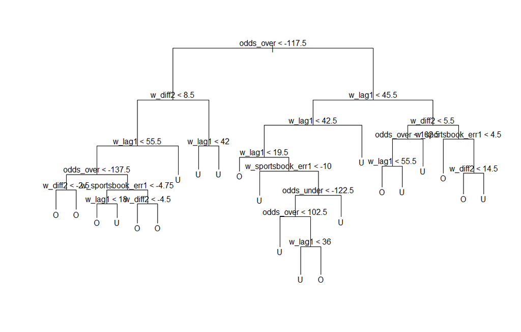

```r
plot(tree_0_fit_full)
text(tree_0_fit_full, pretty = 0)
```

That’s quite a “busy” tree. It’s difficult to make much from its output.

Now, I’ll look at a tree for the `fmla` that I’ve been using before.